# 01_QC

Author

Qian Hui TAN

Published

June 5, 2023

# 1 01_QC

In this notebook, we perform quality control on our dataset.

# 2 Setup

```r
## If output directory doesn't exist, create it
if(!dir.exists("../output")){
    dir.create("../output")
  }

if(!dir.exists("../output/01_QC")){
    dir.create("../output/01_QC")
  }

output_dir <- "../output/01_QC/"
```

```r
suppressPackageStartupMessages({
    library(dplyr)
    library(readr)
    library(tidyr)
    library(ggplot2)
    library(janitor)
    library(GEOquery)
    library(DESeq2)
    library(reshape2) # melt function
    library(biomaRt)
    library(GenomicFeatures)
    library(scales)
    library(ggrepel)
    library(pheatmap)
    library(viridis)
    library(lubridate)
    library(DT)
})

source("../scripts/R/clustering_functions.R")
source("../scripts/R/ma_plot_function.R")
```

```r
# Generic theme
th <- theme(
         plot.title = element_text(size = 20),
         plot.subtitle = element_text(size = 15),
         axis.title.x = element_blank(),
         axis.title.y = element_blank(),
         axis.text.x = element_text(size = 12),
         axis.text.y = element_text(size = 12))

# PCA theme
pca_th <- theme(plot.title = element_text(size = 20),
         axis.title.x = element_text(size = 15),
         axis.title.y = element_text(size = 15),
         axis.text.x = element_text(size = 12),
         axis.text.y = element_text(size = 12))
```

We first create gene-level annotations:

```r
### --- Get gene-level annotations (run once) --- ###

dr.gtf.db <- makeTxDbFromGFF("../data/annotations/Danio_rerio.GRCz11.102.chr.gtf.gz", format="gtf")
ensembl.genes = genes(dr.gtf.db)

fish = useEnsembl(biomart = "ENSEMBL_MART_ENSEMBL",
                  host = "asia.ensembl.org",
                  dataset = "drerio_gene_ensembl",
                  version = "102") #change host as needed

bm.annotations = getBM(attributes=c("ensembl_gene_id", "entrezgene_id", "gene_biotype", "description", "zfin_id_symbol"), mart=fish, filters="ensembl_gene_id", values=ensembl.genes$gene_id, uniqueRows=TRUE)

ensembl.genes$zfin_id_symbol = bm.annotations$zfin_id_symbol[ match(ensembl.genes$gene_id, bm.annotations$ensembl_gene_id) ]
ensembl.genes$gene_biotype = bm.annotations$gene_biotype[ match(ensembl.genes$gene_id, bm.annotations$ensembl_gene_id) ]
ensembl.genes$status = bm.annotations$status[ match(ensembl.genes$gene_id, bm.annotations$ensembl_gene_id) ]
ensembl.genes$description = bm.annotations$description[ match(ensembl.genes$gene_id, bm.annotations$ensembl_gene_id) ]
ensembl.genes$entrezgene_id = bm.annotations$entrezgene_id[ match(ensembl.genes$gene_id, bm.annotations$ensembl_gene_id) ]


# save this as RDS so we don't have to keep running it
saveRDS(bm.annotations, file = "../output/01_QC/bm_annotations.RDS")
saveRDS(ensembl.genes, file = "../output/01_QC/ensembl.genes.RDS")
```

```r
ensembl.genes <- readRDS("../output/01_QC/ensembl.genes.RDS")
```

# 3 Preparing objects for DESeq

## 3.1 Creating the data matrix

```r
body = read.delim("../data/rawCounts_Body.txt", sep = "")

# Make gene names as rownames
rownames(body) <- body$X
body <- body[ ,-1]
```

```r
data = body

# DESeq needs read counts to be integers
data_mat = apply(round(data), c(1,2), as.integer)

head(data_mat)
```

```
                   CCSER1_M_Body_R1 CCSER1_M_Body_R2 CCSER1_M_Body_R3
ENSDARG00000000001               46               34               29
ENSDARG00000000002              649              413              421
ENSDARG00000000018              170              168              165
ENSDARG00000000019              571              621              477
ENSDARG00000000068              746             1123              678
ENSDARG00000000069              391              455              393
                   CCSER1_M_Body_R4 CCSER1_M_Body_R5 CCSER1_M_Body_R6
ENSDARG00000000001               50               50               39
ENSDARG00000000002              487              596              437
ENSDARG00000000018              214              169              244
ENSDARG00000000019              568              683              576
ENSDARG00000000068              791             1080              973
ENSDARG00000000069              387              518              435
                   CCSER1_S_Body_R1 CCSER1_S_Body_R2 CCSER1_S_Body_R3
ENSDARG00000000001               27               38               27
ENSDARG00000000002              349              601              437
ENSDARG00000000018              207              196              223
ENSDARG00000000019              570              714              563
ENSDARG00000000068              901             1040              892
ENSDARG00000000069              508              495              531
                   CCSER1_S_Body_R4 CCSER1_S_Body_R5 CCSER1_S_Body_R6
ENSDARG00000000001               42               54               36
ENSDARG00000000002              386              387              625
ENSDARG00000000018              202              200              175
ENSDARG00000000019              640              585              565
ENSDARG00000000068             1026              931              910
ENSDARG00000000069              544              460              508
                   WT_Body_R1 WT_Body_R2 WT_Body_R3 WT_Body_R4 WT_Body_R5
ENSDARG00000000001         46         25         47         33         48
ENSDARG00000000002        440        451        619        421        444
ENSDARG00000000018        357        281        247        336        283
ENSDARG00000000019        649        457        589        561        635
ENSDARG00000000068       1259       1176        992        939        948
ENSDARG00000000069        674        631        564        548        703
                   WT_Body_R6
ENSDARG00000000001         17
ENSDARG00000000002        622
ENSDARG00000000018        155
ENSDARG00000000019        528
ENSDARG00000000068        812
ENSDARG00000000069        441
```

## 3.2 Metadata wrangling

```r
df <- tibble(sample_id = colnames(body))

# WT metadata
df_wt <- df[grep("WT", df$sample_id),] %>%
  separate(sample_id, into = c("condition", "part", "replicate"),
           remove = FALSE)


# non WT metadata
df_ccser1 <- df[grep("CCSER1", df$sample_id),] %>%
  separate(sample_id, into = c("gene", "mutant_type", "part", "replicate"),
           remove = FALSE) %>%
  unite(col = "condition", gene:mutant_type)

# combine
experimental_metadata <- rbind(df_wt, df_ccser1)

head(experimental_metadata)
```

| sample_id | condition | part | replicate |
| --- | --- | --- | --- |
| WT_Body_R1 | WT | Body | R1 |
| WT_Body_R2 | WT | Body | R2 |
| WT_Body_R3 | WT | Body | R3 |
| WT_Body_R4 | WT | Body | R4 |
| WT_Body_R5 | WT | Body | R5 |
| WT_Body_R6 | WT | Body | R6 |

Fix sample order:

```r
#sample_order <- c("WT_1", "WT_2", "WT_3",
#                  "A9_1", "A9_2", "A9_3",
#                  "C11_1", "C11_2", "C11_3")

#experimental_metadata$sample_id <- factor(experimental_metadata$sample_id,
#                                          levels = sample_order)


# Specifying which group is the control group to make appropriate contrasts downstream
experimental_metadata$condition <- factor(experimental_metadata$condition)
experimental_metadata$condition <- relevel(experimental_metadata$condition, ref = "WT")
```

DESeq needs the `data_mat` and `experimental_metadata` to be in the same order! Make sure this is the case.

Check that data_mat has the same order

```r
data_mat <- data_mat[ ,experimental_metadata$sample_id]
```

```r
data_mat_nonzero = data_mat[rowSums(data_mat) > 0, ] # Remove non-zero rows
```

## 3.3 How many non-zero rows?

How many genes are there in the zebrafish genome?

```r
nrow(data_mat)
```

```
[1] 32520
```

How many genes are expressed (at least 1 read in at least 1 sample)?

```r
nrow(data_mat_nonzero)
```

```
[1] 27321
```

What percentage is this?

```r
nrow(data_mat_nonzero)/nrow(data_mat) * 100
```

```
[1] 84.01292
```

## 3.4 Create DESeq object

```r
# Create DESeq object
dds = DESeqDataSetFromMatrix(data_mat_nonzero, experimental_metadata, ~ condition)
colnames(dds) = colnames(data_mat_nonzero)

# Relevel coldata
colData(dds)$condition <- as.factor(as.character(colData(dds)$condition))

colnames(dds)
```

```
 [1] "WT_Body_R1"       "WT_Body_R2"       "WT_Body_R3"       "WT_Body_R4"
 [5] "WT_Body_R5"       "WT_Body_R6"       "CCSER1_M_Body_R1" "CCSER1_M_Body_R2"
 [9] "CCSER1_M_Body_R3" "CCSER1_M_Body_R4" "CCSER1_M_Body_R5" "CCSER1_M_Body_R6"
[13] "CCSER1_S_Body_R1" "CCSER1_S_Body_R2" "CCSER1_S_Body_R3" "CCSER1_S_Body_R4"
[17] "CCSER1_S_Body_R5" "CCSER1_S_Body_R6"
```

```r
# Sanity check- make sure that rownames and sample ids for dds match

if(all(rownames(colData(dds)) == colData(dds)$sample_id)){
  print("Sample IDs and rownames match.")
} else {
  stop("Order of data_mat and experimental_metadata don't match. Please check the order.")
}
```

```
[1] "Sample IDs and rownames match."
```

```r
#Estimates the size factors using the "median ratio method" described by Equation 5 in Anders and Huber (2010)
dds <- estimateSizeFactors(dds)
#This function obtains dispersion estimates for a count data set
dds <- estimateDispersions(dds)
#This function transforms the count data to the log2 scale in a way which minimizes differences between samples for rows with small counts
rld <- rlog(dds, blind = TRUE) # use blind = TRUE for QC
```

84% of all rows are nonzero.

# 4 DESeq QC

## 4.1 Dispersion estimates

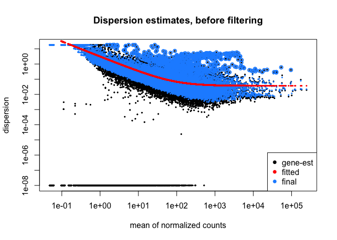

```r
## Plot dispersion estimates
plotDispEsts(dds, main = "Dispersion estimates, before filtering")
```

## 4.2 QC - number of detected genes

Examining our dataset:

```r
dds
```

```
class: DESeqDataSet
dim: 27321 18
metadata(1): version
assays(2): counts mu
rownames(27321): ENSDARG00000000001 ENSDARG00000000002 ...
  ENSDARG00000117826 ENSDARG00000117827
rowData names(10): baseMean baseVar ... dispOutlier dispMAP
colnames(18): WT_Body_R1 WT_Body_R2 ... CCSER1_S_Body_R5
  CCSER1_S_Body_R6
colData names(5): sample_id condition part replicate sizeFactor
```

We plot a few key metrics to check our data quality:

```r
plt_title = "Before Filtering"
```

**Read counts per sample**

```r
total_counts <- as.data.frame(colSums(counts(dds)))
colnames(total_counts) <- "total_counts"
total_counts$name = rownames(total_counts)
```

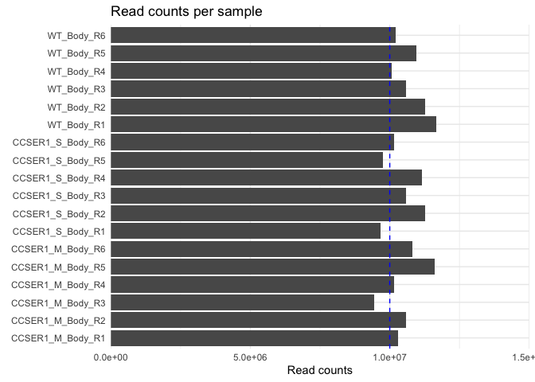

```r
# Plot
ggplot(total_counts, aes(x = name, y = total_counts)) +
    geom_bar(stat = "identity") +
    scale_y_continuous("Read counts",
                       limits = c(0, 1.5e7),
                       expand = c(0, 0),
                       breaks = seq(0, 1.5e7, 5e6)) +
    geom_hline(yintercept = 1e7, color = "blue", linetype = "dashed") +
    labs(title = "Read counts per sample",
         x = element_blank()) +
    theme_minimal() +
    coord_flip()
```

**Number of genes detected per sample**

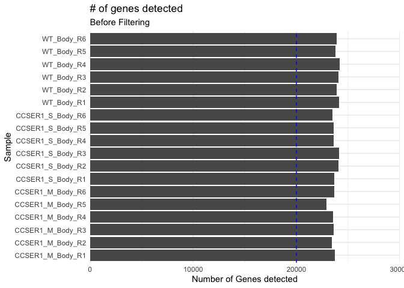

```r
detected = apply(counts(dds), 2, function(col) sum(col > 0 ))
detected = as.data.frame(detected)
detected$name = row.names(detected)

ggplot(detected, aes(x=name, y=detected)) +
                 geom_bar(stat="identity") +
                 theme_minimal() +
                 coord_flip() +
                 scale_y_continuous("Number of Genes detected", expand=c(0,0),
                                    limits = c(0, 30000)
                                    ) +
                 scale_x_discrete("Sample") +
                 labs(title = "# of genes detected",
                     subtitle = plt_title) +
                 geom_hline(yintercept = 20000, color = "blue", linetype = "dashed")
```

**Size factors**

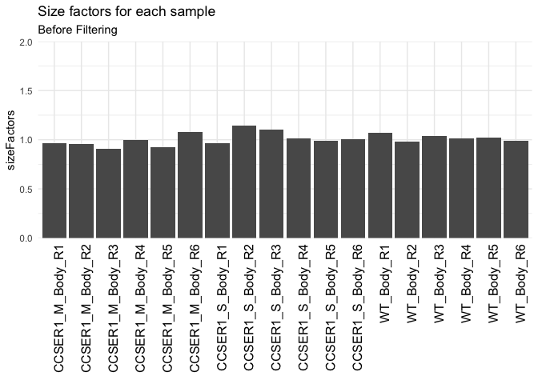

```r
df = data.frame(sample_id = names(sizeFactors(dds)),
                sizeFactors = sizeFactors(dds))

ggplot(df, aes(x = sample_id, y=sizeFactors)) +
    geom_bar(stat="identity") +
    scale_y_continuous(limits=c(0,2), expand=c(0,0)) +
    labs(title = "Size factors for each sample",
         subtitle = plt_title,
         x = element_blank()) +
    theme_minimal() +
    theme(axis.text.x = element_text(angle = 90, hjust=1,
                                     colour="black", size= 12))
```

**Normalized counts (boxplot)**

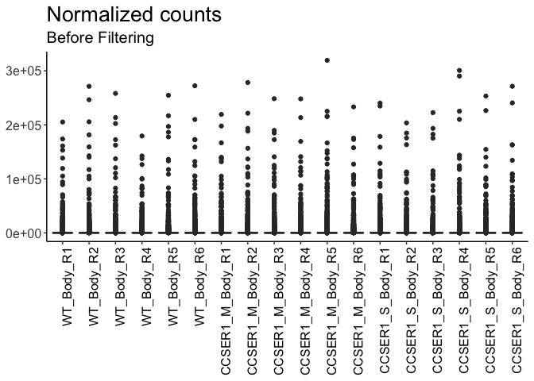

```r
nc = counts(dds, normalized=TRUE)
nc.melt = melt(nc)

ggplot(nc.melt, aes(x=Var2, y=value)) +
    geom_boxplot() +
    theme_classic() +
    theme(axis.text.x = element_text(angle = 90, colour="black", hjust = 1,
                                     size = 12)) +
    scale_x_discrete("Sample") +
    scale_y_continuous("Normalised counts") +
    labs(title = "Normalized counts",
        subtitle = plt_title) +
    th
```

```r
nc.threshold = 2e5
test = apply(nc, 1, function(x){ any(x > nc.threshold) })
```

```r
above_threshold <- as.data.frame(ensembl.genes[names(test[test])])

above_threshold[ ,colnames(above_threshold) %in%
                   c("gene_id", "gene_biotype", "zfin_id_symbol")]
```

|  | gene_id | zfin_id_symbol | gene_biotype |
| --- | --- | --- | --- |
| ENSDARG00000002768 | ENSDARG00000002768 | pvalb2 | protein_coding |
| ENSDARG00000053254 | ENSDARG00000053254 | mylpfa | protein_coding |
| ENSDARG00000067990 | ENSDARG00000067990 | myhz1.1 | protein_coding |
| ENSDARG00000095930 | ENSDARG00000095930 | myha | protein_coding |
| ENSDARG00000099197 | ENSDARG00000099197 | actc1b | protein_coding |

All are protein_coding genes.

Plotting the rRNA graph:

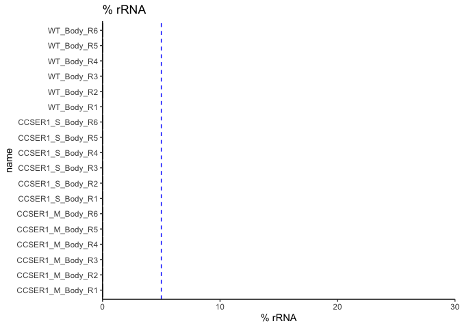

```r
rrna.genes = names(ensembl.genes[ensembl.genes$gene_biotype %in% c("Mt_rRNA", "rRNA")])
percentage.of.rrna = (colSums(counts(dds[ rownames(counts(dds)) %in% rrna.genes])) / colSums(counts(dds))) * 100

percentage.of.rrna = as.data.frame(percentage.of.rrna)
percentage.of.rrna$name = row.names(percentage.of.rrna)
#percentage.of.rrna$name = factor(percentage.of.rrna$name,rev(experimental_metadata$sample_id))
ggplot(percentage.of.rrna,
       aes(x=name, y=percentage.of.rrna)) +
        geom_hline(yintercept = 5, color = "blue", linetype = "dashed") +
        geom_bar(stat="identity") +
        theme_classic() +
        coord_flip() +
        scale_y_continuous("% rRNA", expand=c(0,0), limits = c(0, 30)) +
        labs(title = "% rRNA")
```

Checking summary statistics for rRNA:

```r
summary(percentage.of.rrna$percentage.of.rrna)
```

```
   Min. 1st Qu.  Median    Mean 3rd Qu.    Max.
0.03349 0.05205 0.06324 0.06014 0.06728 0.07497
```

**Proportions of gene biotypes**

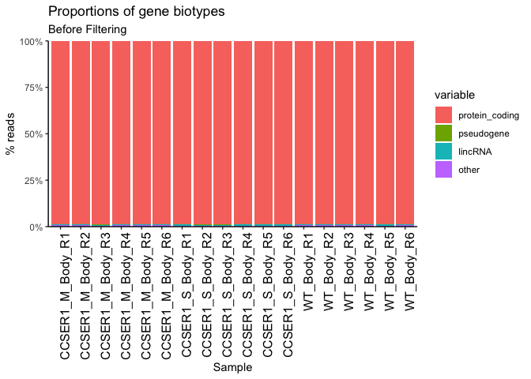

```r
pc = ensembl.genes$gene_id[ensembl.genes$gene_biotype == "protein_coding"]
pg = ensembl.genes$gene_id[ensembl.genes$gene_biotype %in% unique(ensembl.genes$gene_biotype)[grep("pseudogene", unique(ensembl.genes$gene_biotype))]]
lc = ensembl.genes$gene_id[ensembl.genes$gene_biotype == "lincRNA"]

totalcounts.pc = colSums(counts(dds)[rownames(counts(dds)) %in% pc,])
totalcounts.pg = colSums(counts(dds)[rownames(counts(dds)) %in% pg,])
totalcounts.lc = colSums(counts(dds)[rownames(counts(dds)) %in% lc,])

totalcounts.other = colSums(counts(dds)[!(rownames(counts(dds)) %in% c(lc,pc,pg)),])

counts.by.biotype = data.frame(name = names(totalcounts.pc),
                         protein_coding = totalcounts.pc,
                         pseudogene = totalcounts.pg,
                         lincRNA = totalcounts.lc,
                         other = totalcounts.other

                         )

#counts.by.biotype$name = factor(counts.by.biotype$name, experimental_metadata$sample_id)

counts.by.biotype = as.data.frame(t(apply(counts.by.biotype[,2:5], 1, function(x){ 100 * (x / sum(x)) }) ))
counts.by.biotype$name = names(totalcounts.pc)
#counts.by.biotype$name = factor(counts.by.biotype$name, #experimental_metadata$sample_id)

counts.by.biotype.melt = melt(counts.by.biotype)
ggplot(counts.by.biotype.melt, aes(x=name, y=value, fill=variable)) +
    geom_bar(stat="identity") +
    theme_classic() +
    scale_y_continuous("% reads", labels = dollar_format(suffix = "%", prefix = ""),
                       expand=c(0,0)) + scale_x_discrete("Sample") +
    theme(axis.text.x = element_text(angle = 90, colour="black", #family="Arial",
                                     hjust = 1, size=12)) +
    labs(title = "Proportions of gene biotypes",
        subtitle = plt_title)
```

Most genes are protein-coding, as expected.

## 4.3 QC - clustering

We perform 3 types of Quality Control to assess our DESeq dataset:

- Correlation matrix heatmap
- Hierarchical clustering
- PCA

**Correlation matrix heatmap**

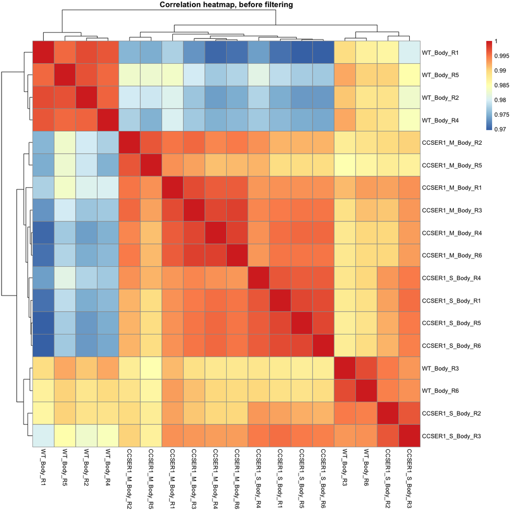

```r
### Extract the rld matrix from the object
rld_mat <- assay(rld)
### Compute pairwise correlation values
rld_cor <- cor(rld_mat)
### Plot heatmap
pheatmap(rld_cor, main = "Correlation heatmap, before filtering")
```

**Hierarchical clustering**

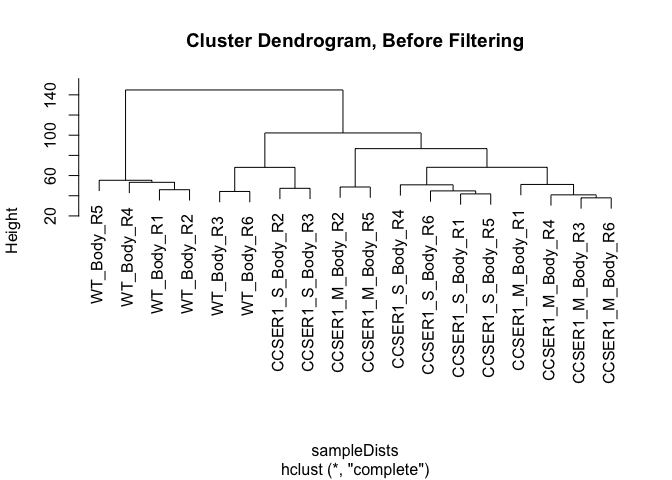

```r
sampleDists <- dist(t(assay(rld)))
plot(hclust(sampleDists), main = paste0("Cluster Dendrogram, ", plt_title))
```

**PCA**

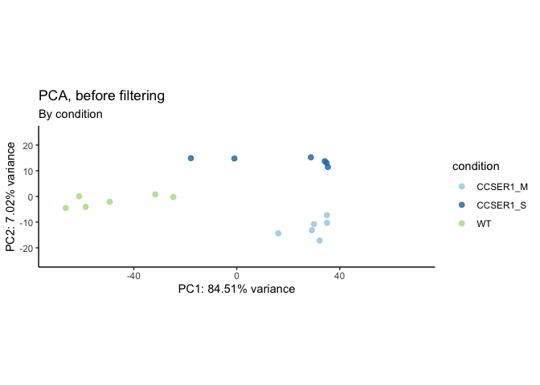

```r
make_pca(rld, intgroup = "condition",
         title = "PCA, before filtering")
```

**PCA, labelled**

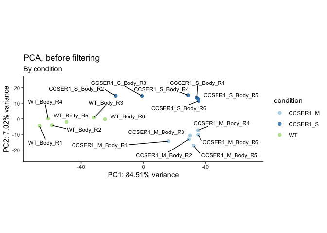

```r
make_pca(rld, intgroup = "condition", label = TRUE,
         title = "PCA, before filtering")
```

**PCA, by size factor**

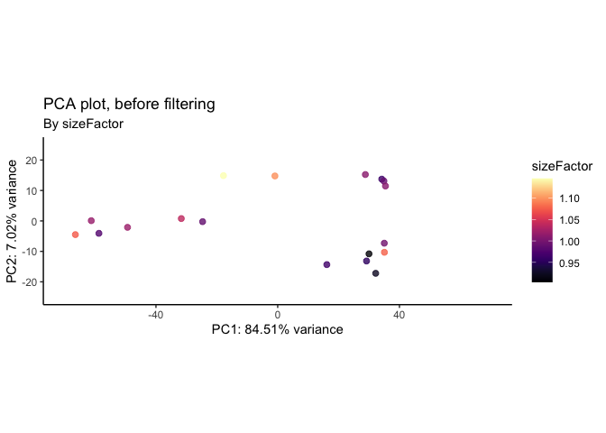

```r
make_pca(rld, intgroup = "sizeFactor",
         title = "PCA plot, before filtering") +
  scale_color_viridis(option = "A")
```

This looks good - PC1 and 2 both capture biological variation. Samples also cluster within conditions.

All our key metrics look good. Read counts per sample, number of genes per sample are all high, and relatively similar across all samples. Most genes are protein-coding, as expected. Data is of high quality.

# 5 Remove rRNA and mitochondrial genome

We remove all genes that map to rRNA, as well as the mitochondrial chromosome before we proceed with downstream analysis.

```r
plt_title = "after removing rRNA and mitochondrial genome"
```

Checking MT chromosome intact:

```r
in_dds = ensembl.genes[na.omit(match(rownames(counts(dds)), ensembl.genes$gene_id)), ]
table(seqnames(in_dds))
```

```
   1    2    3    4    5    6    7    8    9   10   11   12   13   14   15   16
1256 1330 1447 1703 1431 1072 1488 1113  953  947  922  886  948  891 1009 1138
  17   18   19   20   21   22   23   24   25   MT
 960  839  982 1068  964 1089  962  734  838   16
```

Remove MT chromosome, rerun DESeq:

```r
# Remove mitochondrial genome
mit_genes <- ensembl.genes[seqnames(ensembl.genes) %in% "MT", ]$gene_id
dds_rm_mit <- dds[!rownames(counts(dds)) %in% mit_genes, ]

# Remove rRNA
dds_filt = dds_rm_mit[!(row.names(counts(dds_rm_mit)) %in%
                   ensembl.genes$gene_id[ensembl.genes$gene_biotype %in%
                                           c("rRNA", "snoRNA", "snRNA", "Mt_rRNA")]), ]
dds_filt = dds_filt[rowSums(counts(dds_filt)) > 0, ]

# Re-estimate dispersions
dds_filt <- estimateSizeFactors(dds_filt)
dds_filt <- estimateDispersions(dds_filt)
```

```
found already estimated dispersions, replacing these
```

```r
rld_filt <- rlog(dds, blind = TRUE) # use blind = TRUE for QC
```

Check that mitochondrial genome has been removed:

```r
in_dds = ensembl.genes[na.omit(match(rownames(counts(dds_filt)), ensembl.genes$gene_id)), ]
table(seqnames(in_dds))
```

```
   1    2    3    4    5    6    7    8    9   10   11   12   13   14   15   16
1250 1321 1446 1693 1426 1070 1481 1112  951  945  921  886  947  889 1009 1136
  17   18   19   20   21   22   23   24   25   MT
 960  836  978 1057  961 1089  959  733  835    0
```

## 5.1 Check rRNA removed

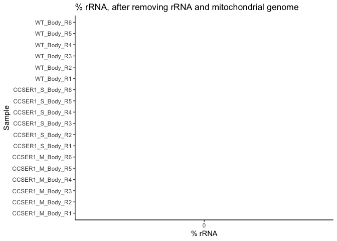

```r
rrna.genes = names(ensembl.genes[ensembl.genes$gene_biotype %in% c("Mt_rRNA", "rRNA",
                                                                   "snoRNA", "snRNA")])

percentage.of.rrna = (colSums(counts(dds_filt[rownames(counts(dds_filt)) %in% rrna.genes])) / colSums(counts(dds_filt))) * 100
percentage.of.rrna = as.data.frame(percentage.of.rrna)
percentage.of.rrna$name = row.names(percentage.of.rrna)
#percentage.of.rrna$name = factor(percentage.of.rrna$name, rev(experimental_metadata$sample_id))


ggplot(percentage.of.rrna, aes(x=name, y=percentage.of.rrna)) +
  geom_bar(stat="identity") + theme_classic() + coord_flip() + scale_y_continuous("% rRNA", expand=c(0,0)) +
  scale_x_discrete("Sample") +
  ggtitle(paste0("% rRNA, ", plt_title))
```

Checking that rRNA percentage is now zero:

```r
summary(percentage.of.rrna$percentage.of.rrna)
```

```
   Min. 1st Qu.  Median    Mean 3rd Qu.    Max.
      0       0       0       0       0       0
```

## 5.2 QC - number of genes

**Size Factors after rRNA removal**

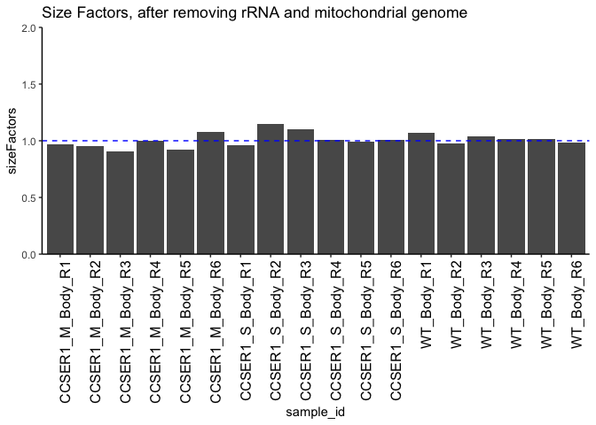

```r
df = data.frame(sample_id = names(sizeFactors(dds_filt)), sizeFactors = sizeFactors(dds_filt))

ggplot(df, aes(x = sample_id, y=sizeFactors)) +
  geom_bar(stat="identity") +
  scale_y_continuous(limits=c(0,2), expand=c(0,0)) +
  theme_classic() +
  theme(axis.text.x = element_text(angle = 90, hjust=1, colour="black", size=12)) +
  geom_hline(yintercept = 1, color = "blue", linetype = "dashed") +
  ggtitle(paste0("Size Factors, ", plt_title))
```

Summary of size factors:

```r
summary(sizeFactors(dds_filt))
```

```
   Min. 1st Qu.  Median    Mean 3rd Qu.    Max.
 0.9039  0.9681  1.0022  1.0080  1.0325  1.1452
```

Size factors for each sample:

```r
print(sizeFactors(dds_filt))
```

```
      WT_Body_R1       WT_Body_R2       WT_Body_R3       WT_Body_R4
       1.0735888        0.9769747        1.0370124        1.0168888
      WT_Body_R5       WT_Body_R6 CCSER1_M_Body_R1 CCSER1_M_Body_R2
       1.0187779        0.9878447        0.9651164        0.9527000
CCSER1_M_Body_R3 CCSER1_M_Body_R4 CCSER1_M_Body_R5 CCSER1_M_Body_R6
       0.9038935        0.9964862        0.9236517        1.0764546
CCSER1_S_Body_R1 CCSER1_S_Body_R2 CCSER1_S_Body_R3 CCSER1_S_Body_R4
       0.9617552        1.1452030        1.0991897        1.0094724
CCSER1_S_Body_R5 CCSER1_S_Body_R6
       0.9904995        1.0078157
```

**Read counts per sample after rRNA and chrM removal**

```r
total_counts <- as.data.frame(colSums(counts(dds_filt)))
colnames(total_counts) <- "total_counts"
total_counts$name = rownames(total_counts)
```

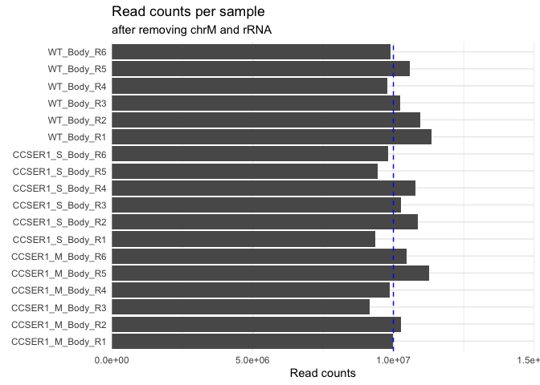

```r
# Plot
ggplot(total_counts, aes(x = name, y = total_counts)) +
    geom_bar(stat = "identity") +
    scale_y_continuous("Read counts",
                       limits = c(0, 1.5e7),
                       expand = c(0, 0),
                       breaks = seq(0, 1.5e7, 0.5e7)) +
    geom_hline(yintercept = 1e7, color = "blue", linetype = "dashed") +
    labs(title = "Read counts per sample",
         subtitle = "after removing chrM and rRNA",
         x = element_blank()) +
    theme_minimal() +
    coord_flip()
```

**Number of genes detected per sample after rRNA and chrM removal**

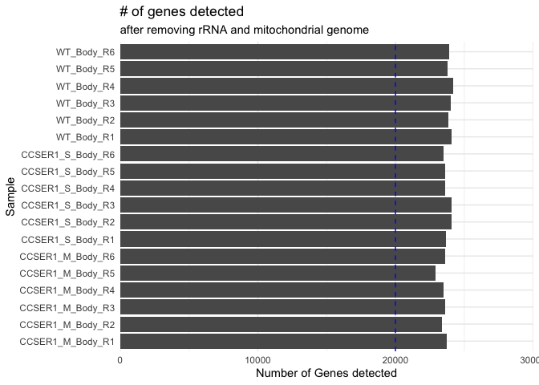

```r
detected = apply(counts(dds_filt), 2, function(col) sum(col > 0 ))
detected = as.data.frame(detected)
detected$name = row.names(detected)
#detected$name = factor(detected$name, rev(experimental_metadata$sample_id))

ggplot(detected, aes(x=name, y=detected)) +
                 geom_bar(stat="identity") +
                 theme_minimal() +
                 coord_flip() +
                 scale_y_continuous("Number of Genes detected", expand=c(0,0),
                                    limits = c(0, 30000)) +
                 scale_x_discrete("Sample") +
                 labs(title = "# of genes detected",
                     subtitle = plt_title) +
                 geom_hline(yintercept = 20000, color = "blue", linetype = "dashed")
```

## 5.3 QC- clustering

**Heatmap after rRNA removal**

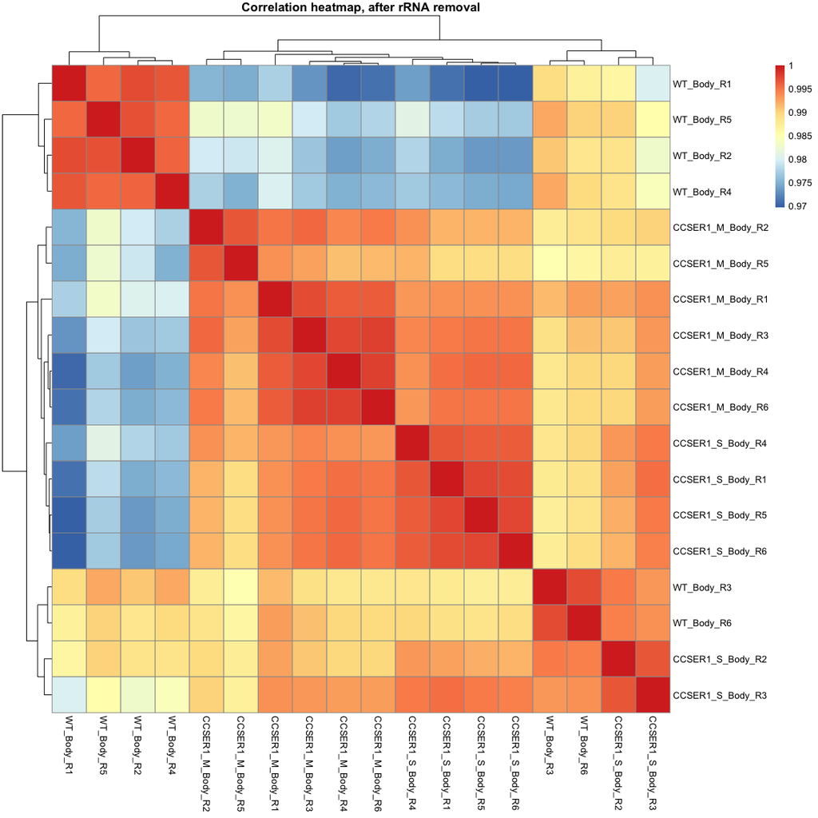

```r
### Extract the vst matrix from the object
rld_mat <- assay(rld_filt)

### Compute pairwise correlation values
rld_cor <- cor(rld_mat)

### Plot heatmap
pheatmap(rld_cor, main = "Correlation heatmap, after rRNA removal")
```

**Clustering after rRNA removal**

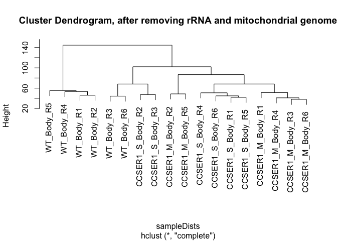

```r
sampleDists <- dist(t(assay(rld_filt)))
plot(hclust(sampleDists), main = paste0("Cluster Dendrogram, ", plt_title))
```

**PCA after rRNA removal**

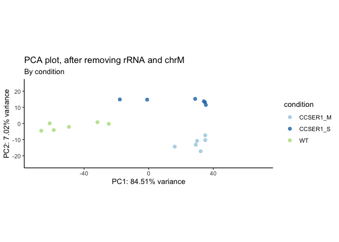

```r
make_pca(rld_filt, intgroup = "condition",
         title = "PCA plot, after removing rRNA and chrM")
```

**PCA, labelled**

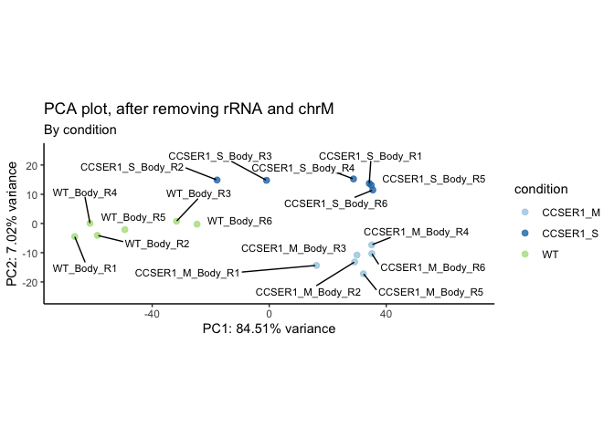

```r
make_pca(rld_filt, intgroup = "condition", label = TRUE,
         title = "PCA plot, after removing rRNA and chrM")
```

**PCA, by size factor**

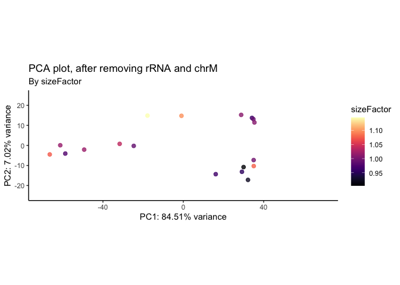

```r
make_pca(rld_filt, intgroup = "sizeFactor",
         title = "PCA plot, after removing rRNA and chrM") +
  scale_color_viridis(option = "A")
```

# 6 Check CCSER1 levels

We plot the normalized counts of CCSER1 in each sample:

```r
ccser1_gene <- "ENSDARG00000075919"

# The normalized counts
ccser1_norm <- as.data.frame(counts(dds_filt, normalized = TRUE)[ccser1_gene, ])

ccser1_norm$sample <- rownames(ccser1_norm)
colnames(ccser1_norm) <- c("counts", "sample")
head(ccser1_norm)
```

|  | counts | sample |
| --- | --- | --- |
| WT_Body_R1 | 55.88732 | WT_Body_R1 |
| WT_Body_R2 | 51.17840 | WT_Body_R2 |
| WT_Body_R3 | 36.64373 | WT_Body_R3 |
| WT_Body_R4 | 68.83742 | WT_Body_R4 |
| WT_Body_R5 | 33.37332 | WT_Body_R5 |
| WT_Body_R6 | 45.55372 | WT_Body_R6 |

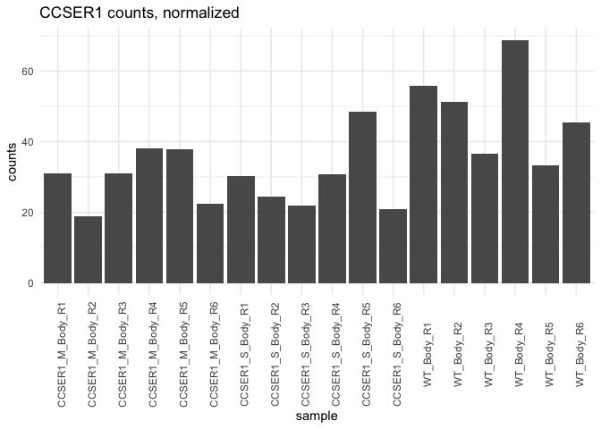

```r
ggplot(ccser1_norm, aes(x = sample, y = counts)) +
  geom_col() +
  labs(title = "CCSER1 counts, normalized") +
  theme_minimal() +
  theme(axis.text.x = element_text(angle = 90))
```

# 7 MA plots

Plots to assess whether samples are good replicates.

**WT**

```r
plot_ma_by_rep(condition_combis = generate_condition_combinations(dds_filt, "WT"))
```

[output not shown]

**CCSER1_M**

```r
plot_ma_by_rep(condition_combis = generate_condition_combinations(dds_filt, "CCSER1_M"))
```

[output not shown]

**CCSER1_S**

```r
plot_ma_by_rep(condition_combis = generate_condition_combinations(dds_filt, "CCSER1_S"))
```

[output not shown]

# 8 Save output

```r
saveRDS(ensembl.genes, file = paste0(output_dir, "ensembl_genes.RDS"))
saveRDS(data_mat, file = paste0(output_dir, "data_mat.RDS"))
saveRDS(experimental_metadata, file = paste0(output_dir, "metadata.RDS"))
saveRDS(dds_filt, file = paste0(output_dir, "dds_filt.RDS"))
```

# 9 Summary

- Everything looks good!
- Possible batch effect with R3 and R6?
- Same conditions cluster together on the PCA, as expected.